# Linear Regression: Model Specification, Comparison, and Interpretation

Author

Ali Naeij

| Variable | Mean | SD | Min | Max |
| --- | --- | --- | --- | --- |
| complaints | 66.60 | 13.31 | 37 | 90 |
| learning | 56.37 | 11.74 | 34 | 75 |
| raises | 64.63 | 10.40 | 43 | 88 |
| rating | 64.63 | 12.17 | 40 | 85 |

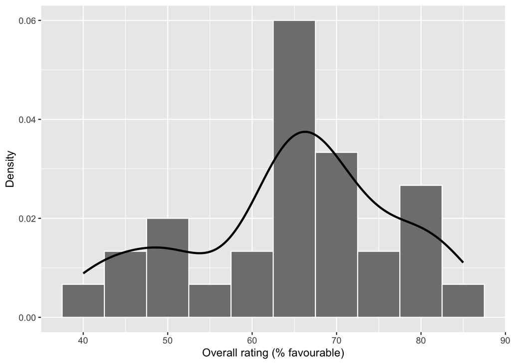

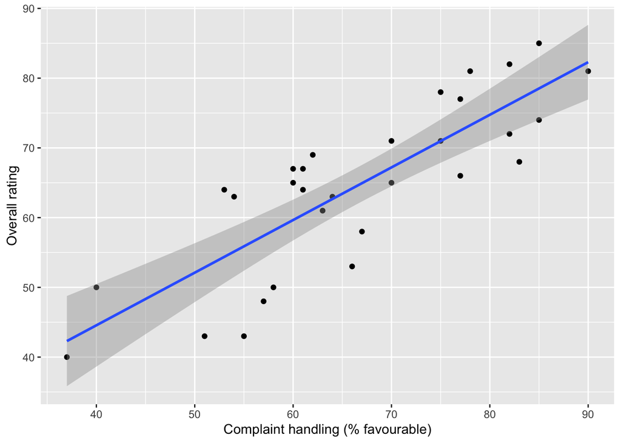

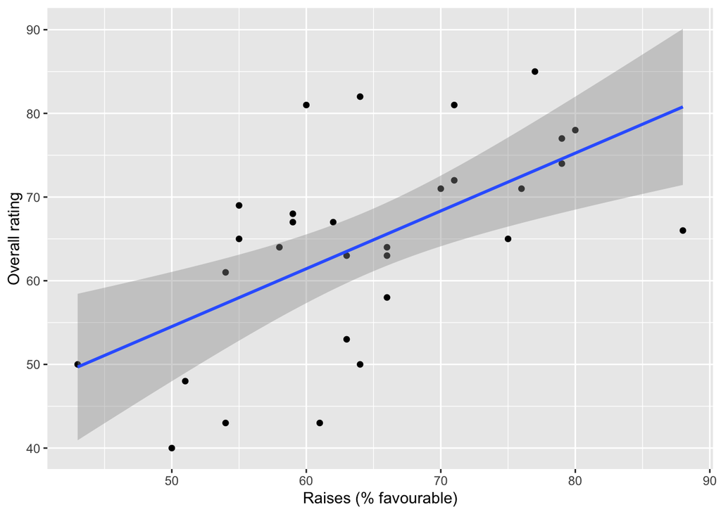

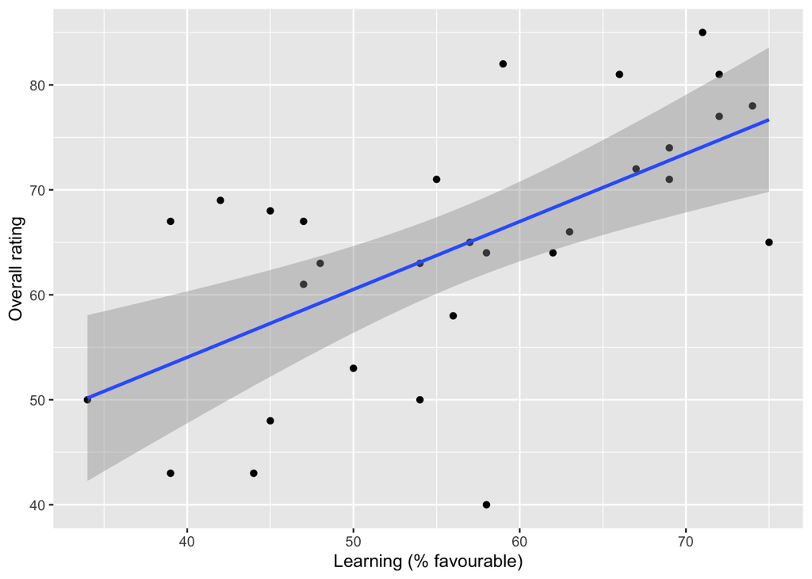

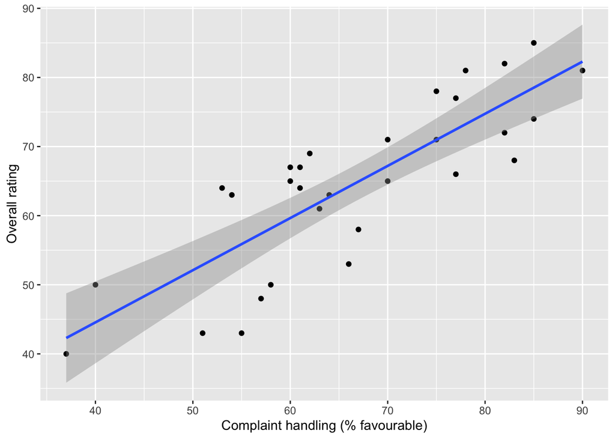

## Exploring the Data

The attitude dataset summarizes survey responses from clerical employees in 30 departments of a financial organization. Each variable is the percentage of a department’s employees responding favourably. The outcome of interest is the overall job rating (`rating`), and the predictors of interest are `complaints` (how employee complaints are handled), `learning` (opportunity to learn), and `raises` (raises provided based on performance).

The lowest reported overall rating by any department was 40%, and thehighest was 85%, with ratings centred around 65%. The distribution had a single main peak with a slightly longer lower tail, and no department fell far outside the range of the others.

All predictors were positively associated with overall rating, and the relationships appeared approximately linear. Complaint handling showed the strongest relationship, with points clustered tightly around the fitted line. Learning and raises were more scattered. This matches my expectation that complaint handling, which reflects how supervisors respond to everyday problems, would be more closely tied to overall ratings than learning or raises. Two departments stood out. Department 24 had the lowest overall rating (40%) and the lowest complaint-handling score (37%), but it fell close to the complaints trend line, so it was extreme without departing from the overall pattern. Department 26 reported the most favourable view of raises (88%) but only an average overall rating (66%), placing it well below the fitted line for raises. Neither appeared extreme enough to suggest a data error, but both are worth monitoring in the regression diagnostics.

## Predictions

**Why would complaint handling be tied to how people rate their joboverall?**

Complaint handling is reflects how supervisors treat employees on a daily basis. In departments where problems are listened to and resolved, employees are likely to feel valued, which should carry over into how they rate the job overall. Complaint handling also tends to occur more frequently, unlike raises or learning opportunities, which would happen less frequently, so it may shape everyday experience more directly. I therefore expected complaint handling to show the strongest association with overall rating.

**Could opportunities for learning explain additional variation beyond complaint handling** Learning reflects growth and development, which is a different aspect of the job from how complaints are handled, as such, learning opportunities could plausibly explain additional variation in ratings. However, it would stand to reason that departments with supportive supervisors would probably have better learning opportunities as well as better handling of complaints, so part of what learning explains may already be captured by complaints. Learning opportunities could also cause stress in some individuals, potentially reducing satisfaction. I expected learning to make a modest additional contribution, potentially smaller than its correlation with rating alone.

**Could raises explain additional variation beyond complaint handling** Pay is a concrete, tangible reward, however, raises are closely tied to performance and would depend on supervisors as well, as such raises probably overlap with both complaint handling and learning. If an employee already likes their role, they are more likely to spend more time at work, or trying harder at work, thus showing greater performance metrics than their peers, and will be more likely to receive a raise. Raises also happen rarely, so they may have a lesser effect on day-to-day satisfaction. I expected raises to add little once complaint handling and learning were accounted for.

**Nested Models** In `m1`, the `complaints` coefficient was 0.755. This essentially means that each 1 percentage-point higher complaint handling had, on average, a 0.755-point higher overall rating. Because learning was not in the model, this estimate also absorbed any association that complaint handling shares with learning. When `learning` was added in `m2`, the coefficient decreased to 0.644, now reflecting the association among departments with similar learning scores. Basically, `m2` answers the following question: “among departments with the same learning score, how much higher is rating for each extra point of complaint handling?” Adding raises in `m3` had little effect on the coefficient (0.653), this suggests that `raises` contributed little information beyond complaint handling and learning.

| Model | Overall performance R² | Overall performance Adjusted R² | Overall performance RMSE | Incremental improvement ΔR² | Incremental improvement Residual df | Incremental improvement Nested df | Incremental improvement Nested F | Incremental improvement Nested p |
| --- | --- | --- | --- | --- | --- | --- | --- | --- |
| M0 | 0.000 | 0.000 | 11.97 | — | 29 | — | — | — |
| M1 | 0.681 | 0.670 | 6.76 | 0.681 | 28 | 1 | 60.73 | <0.001 |
| M2 | 0.708 | 0.686 | 6.47 | 0.027 | 27 | 1 | 2.38 | 0.135 |
| M3 | 0.708 | 0.675 | 6.46 | 0.000 | 26 | 1 | 0.02 | 0.876 |

## Comparison Interpretation

**NoteClick to expand**

**Which model explains the most variation?**

`m2` and `m3` are essentially tied (R<sup>2</sup> = 0.708), with `m3` higher only in the fourth decimal place, because R<sup>2</sup> can never go down when a predictor is added.

**How does adjusted R<sup>2</sup> change?**

The adjusted R<sup>2</sup> goes from 0.670 (`m1`) -> 0.686 (`m2`) -> 0.675 (`m3`). It rises when learning is added and falls when raises is added. That means raises costs more in complexity than it adds in fit.

**How much does each model contribute (R<sup>2</sup>)**

Complaints: 0.681, about 68% of the variation; Learning: 0.027, about 3% more; Raises: about 0.000, essentially nothing.

**Which additions are statistically significant?**

Complaints: F(1, 26) = 60.73, p < 0.001. Significant. Learning: F(1, 26) = 2.38, p = 0.135. Not significant. Raises: F(1, 26) = 0.02, p = 0.877. Not significant.

**Are the RMSE reductions meaningful?**

`m0` → `m1`: about 12.0 → 6.8, a drop of more than 5 points. Prediction error is nearly halved, which is clearly meaningful. `m1` → `m2`: about 0.3 points. Small on a 0–100 scale. `m2` → `m3`: about 0.01 points. Nothing.

Complaint handling (`complaint`) accounted for most of the explained variation in overall ratings. Compared with the intercept-only model, `m1` explained 68.1% of the variance, F(1, 26) = 60.73, p < 0.001, and reduced RMSE from 11.97 to 6.76 rating points.

Adding learning in `m2` increased R² by a further 2.7 percentage points and raised adjusted R² from 0.670 to 0.686, but this improvement was not statistically significant, F(1, 26) = 2.38, p = 0.135, and RMSE fell by only about 0.3 points.

Adding raises in `m3` produced essentially no change, ΔR² < .001, F(1, 26) = 0.02, p = 0.877, and adjusted R² declined to 0.675, indicating that raises added complexity without improving fit. Although `m2` and `m3` had the largest R² (.708), the pattern suggests that complaint handling captures most of the variation these workplace measures explain in overall ratings. Learning may contribute a small amount of unique information, but the evidence is weak, and raises appears redundant once complaint handling and learning are included. This is consistent with the predictions in Section 2.1 and with the correlations among the predictors.

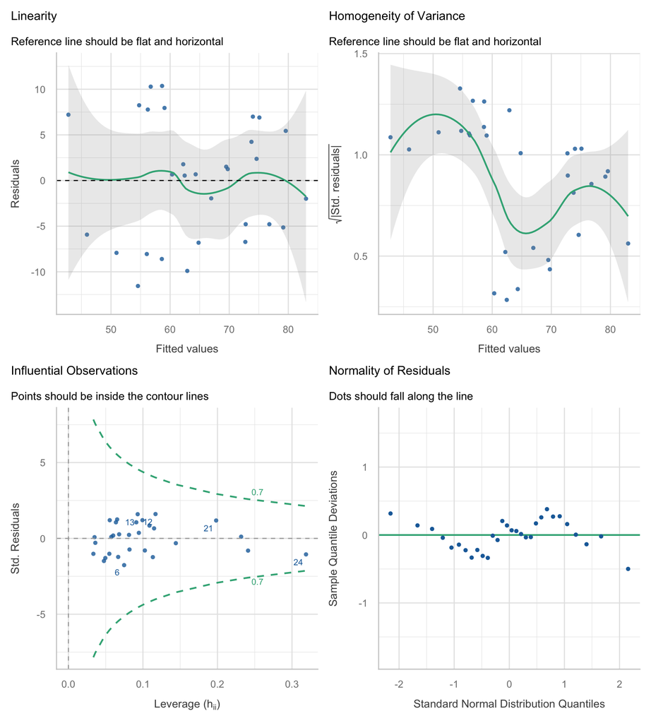

Figure 1

```
OK: residuals appear as normally distributed (p = 0.093).
```

```
OK: Error variance appears to be homoscedastic (p = 0.107).
```

```
OK: No outliers detected.
- Based on the following method and threshold: cook (0.809).
- For variable: (Whole model)
```

```
# Check for Multicollinearity

Low Correlation

       Term  VIF   VIF 95% CI adj. VIF Tolerance Tolerance 95% CI
 complaints 1.55 [1.18, 2.71]     1.25      0.64     [0.37, 0.85]
   learning 1.55 [1.18, 2.71]     1.25      0.64     [0.37, 0.85]
```

## Diagnostic Findings

Diagnostic checks for`m2` indicate that the model’s assumptions are reasonably satisfied. The residuals showed no systematic curvature across fitted values, supporting a linear specification. The Q-Q plot indicated approximately normally distributed residuals. The variance of the residuals was not perfectly uniform, since the departments with lower predicted ratings showed greater spread than those with higher predicted ratings, although the formal test did not detect significant heteroscedasticity (p = 0.107). No department exceeded the threshold for influential observations. Department 24, previously identified as having the lowest overall rating and complaint-handling score, had the highest leverage, but since it also had small residual, it did not exert undue influence on the fitted model. Multicollinearity was low (VIF = 1.55 for both predictors), indicating that, although complaint handling and learning are correlated, their unique contributions could still be estimated with reasonable precision. Overall, these results suggest that we can have confidence in the estimated coefficients. However, with only 30 departments, the diagnostic tests have limited power to detect violations, and that p-values close to the significance threshold, (e.g. learning), should be interpreted with caution.

## Model Selection

`m2` (complaint handling and learning) was selected as the preferred model. It had the highest adjusted R<sup>2</sup> of the four models, suggesting that the improvement from adding learning outweighed the cost of an additional predictor, and it had the lowest RMSE among the models without redundant predictors. Its diagnostics were acceptable. `m1` is a defensible alternative because the improvement from learning was not statistically significant. However, with only 30 departments the F-test has limited power, and the gain in adjusted R² suggests that learning contributes some information. `m3` was not preferred because raises added essentially no explained variance and reduced adjusted R<sup>2</sup>.

| Predictor | b | SE | 95% CI | p |
| --- | --- | --- | --- | --- |
| Intercept | 9.87 | 7.06 | [−4.62, 24.36] | 0.174 |
| Complaint handling | 0.64 | 0.12 | [0.40, 0.89] | <0.001 |
| Learning opportunities | 0.21 | 0.13 | [−0.06, 0.49] | 0.128 |

## Regression Coefficient Interpretation

Holding learning opportunities constant, complaint handling was positively associated with overall rating: each 1 percentage-point increase in complaint-handling responses was associated with a 0.64-point higher overall rating (95% CI:0.4 to 0.89). For example, a department scoring 10 points higher on complaint handling would be expected to have an overall rating about 6.4 points higher. Because the confidence interval excludes zero and is relatively narrow, the data provide clear evidence of a positive association.

Holding complaint handling constant, each one-percentage-point increase in learning responses was associated with a 0.21-point higher overall rating (95% CI: -0.06 to 0.49; p = 0.128). The estimate is positive, but the confidence interval includes zero. This would meant that the data are consistent with anything from no association to a moderately positive association. Learning’s unique contribution is therefore uncertain.

The intercept represents the predicted rating for a department with 0% favourable responses on both predictors. No department in the data is close to this, so the intercept is not meaningful to interpret.

## Model Performance Summary

The selected model explained 70.8% of the variation in overall ratings across departments (adjusted R<sup>2</sup> = 0.686). Its RMSE of 6.47 means that predicted ratings were typically off by about 6.5 percentage points, compared with about 12 points when predicting every department at the mean rating.

## Conclusion

Overall, the results suggest that complaint handling is the most important of the three factors for overall workplace ratings. It accounted for the large majority of explained variation, and its association with rating remained strong and precisely estimated after adjusting for learning opportunities. Learning may make a small additional contribution, but its association with rating was small and statistically uncertain. Pay increases contributed essentially nothing once complaint handling and learning were included. This does not mean that raises are unrelated to ratings, since raises correlated substantially with rating on its own (r = 0.59). Rather, the information raises provides appears to overlap with what complaint handling and learning already capture. These conclusions also depend partly on the order in which predictors were entered: because complaint handling was entered first, it received credit for variance it shares with the other predictors.

Several limitations should be taken into consideration. With only 30 departments, the analysis had limited power to detect small effects, so the non-significant contribution of learning should not be read as evidence of no effect. The data are department-level summaries, so the findings describe departments rather than individual employees and should not be used to draw conclusions about individual attitudes. The design is cross-sectional and correlational, which precludes causal conclusions; for example, departments with more satisfied employees may also perform better and receive more raises, rather than raises producing satisfaction. Because all variables come from the same survey, a general tendency to respond favourably could inflate the associations among them. Finally, the data come from clerical employees in a single organization collected several decades ago, which limits how far the results generalize to other workplaces.